# Préparation de la base JOCAS

Author

Claude Grasland

```r
library(knitr)
## Global options
options(max.print="80")
opts_chunk$set(echo=TRUE,
               cache=FALSE,
               prompt=FALSE,
               tidy=FALSE,
               comment=NA,
               message=FALSE,
               warning=FALSE,
               options(scipen=999))
opts_knit$set(width=75)

# Packages utilitaires
library(dplyr)
library(data.table)
# Packages graphiques
library(ggplot2)

#packages cartographiques
library(sf)
library(mapsf)

# Appel d'API
library(jsonlite)
```

Au cours de cette première étape, nous allons prendre connaissance d’un fichier de très grande taille issu de la base JOCAS puis procéder à une sélection de variable et leur ajouter des métadonnées en vue de leur exploitation.

## Importation du fichier brut

On charge un fichier qui est conforme à la base initiale avec juste une présélection de variables jugées intéressantes.

### Charger le fichier

```r
base<-readRDS("jocas_france/raw/base_raw.RDS")
```

Le fichier se charge rapidement car il a été sauvegardé au format interne de R (.Rdata ou .RDS).

### Vérifier son type et ses dimensions

```r
dim(base)
```

```
[1] 3727995      10
```

```r
class(base)
```

```
[1] "data.frame"
```

Le tableau comporte 3.7 millions de lignes et 10 variables ce qui le classe dans la catégorie des **Big Data**, définie arbirairement comme une base de données comportant plus d’un million d’individus.

### Examiner le type des variables

```r
str(base)
```

```
'data.frame':   3727995 obs. of  10 variables:
 $ date_sitePublicationDay: Date, format: "2020-01-01" "2020-01-01" ...
 $ location_zipcode       : Factor w/ 6593 levels "01000","01090",..: 5570 864 864 4122 4036 2183 5062 NA 2386 4677 ...
 $ location_departement   : Factor w/ 116 levels "","01","02","03",..: 91 18 18 70 70 40 84 1 43 77 ...
 $ location_country       : Factor w/ 96 levels "","Afrique du Sud",..: 1 1 1 1 1 1 1 1 1 1 ...
 $ salary_hourly_mean     : num  13.8 12.9 12.9 10.5 10 ...
 $ job_ROME_code          : Factor w/ 532 levels "","A1101","A1201",..: 160 488 78 104 373 426 373 372 51 315 ...
 $ entrepriseSecteur_NAF21: Factor w/ 20 levels "","C","D","E",..: 5 13 13 13 16 13 19 19 1 14 ...
 $ entrepriseSecteur_NAF88: Factor w/ 87 levels "1","2","3","6",..: 38 68 68 68 77 70 85 85 NA 73 ...
 $ contractType           : Factor w/ 12 levels "CCE","CDD","CDI",..: 2 9 9 2 3 3 2 2 3 2 ...
 $ contractDuration_value : num  130 390 130 260 NA NA 130 173 NA 130 ...
```

Il existe une variable de type *Date*, deux variables de type *numeric* et 7 variables de type *factor*. Le stockage des variable sous la forme *factor* plutôt que *character* a été utilisé pour réduire la taille du fichier .RDS. En effet un facteur ne stocke les étiquettes qu’une seule fois puis note le niveau du facteur 1…n ce qui prend moins de place que le stockage de chaînes de caractères comportant plusieurs caractères.

### Examiner la définition variables

On se reporte au fichier pdf `Description_variables_Jocas_Dedup.pdf` pour trouver la définiton précise de chacun des dix indicateurs sélectionnés :

- **date_sitePublicationDay**: Date de publication de l’offre telle que renseignée sur le site. C’est une information fournie par le site contrairement aux variables précédentes. Ce champ peut être vide. Format : %Y-%m-%d
- **location_zipcode** : Code postal du lieu de travail. C’est le code postal indiqué par le site, si cette donnée est disponible. Sinon la Dares effectue un matching entre « location_label » et les libellés de communes françaises pour retrouver le code postal. Parfois le matching est ambigüe (plusieurs codes postaux pour un même libellé), dans ce cas le code postal reste vide.
- **location_departement** : Département du lieu de travail (départements français ou DOM-TOM). Le département « 99 » correspond à l’étranger.
- **location_country** : Si l’offre est à l’étranger et que le pays étranger est connu, nom du pays étranger. Cette variable est généralement vide car la majorité des offres sont en France.
- **salary_hourly_mean** :Salaire horaire moyen. Calcul selon la métoholodie dans le document methodologique
- **job_ROME_code** : Code métier selon la nomenclature ROME de Pôle emploi. Le code ROME est codé automatiquement à partir de l’intitulé de l’offre (variable « job_title »), grâce à un algorithme décrit dans ce document. Pour l’API Pôle emploi, les offres contiennent déjà le code ROME, codé par Pôle emploi.
- **entrepriseSecteur_NAF21**: Secteur d’activité de l’entreprise selon la nomenclature NAF de l’Insee, au niveau A21.
- **entrepriseSecteur_NAF88**: Secteur d’activité de l’entreprise selon la nomenclature NAF de l’Insee, au niveau A88.
- **contractType** :Type de contrat proposé, tel que renseigné dans les champs structurés des offres. Les catégories ne sont pas homogènes selon les sites. Dans certains cas nous pouvons pas distinguer entre plusieurs contrats. Les differentes valeurs possibles sont : CDI ; CDD ; MIS [Mission d’Intérim] ; Apprentissage ; Alternance ; Independant ; Independant/Franchise ; Stage/Alternance ; Stage ; Apprentissage/Alternance ; CDD/MIS ; CDI/MIS ; Franchise ; Titulaire de la fonction publique ; Contrat étranger ; Contrat de professionnalisation ; VIE ; VIA ; Bénévolat ; CDS [CDD Sénior] ; SAI [Saisonnier] ; CCE [Profession commerciale]; REP [Reprise d’entreprise] ; TTI [Contrat travail temporaire insertion] ; DDI [Contrat durée déterminée insertion] ; DIN [CDI Intérimaire] ; Intermittent ; Contrat d’usage ;Contractuel de la fonction publique ; Avis de concours **contractDuration_value** : Durée moyenne du contrat, exprimée en jours.

## Sélection et enrichissement des variables

Au cours de cette étape on va sélectionner un petit nombre de variables et les enrichir à l’aide de métadonnées.

### La variable **date** (date_sitePublicationDay)

On examine les paramètres de la distribution avec summary()

```r
base$date <-base$date_sitePublicationDay
summary(base$date)
```

```
        Min.      1st Qu.       Median         Mean      3rd Qu.         Max.
"2020-01-01" "2020-03-11" "2020-06-30" "2020-06-22" "2020-09-18" "2020-12-31"
```

- Y-a-t-il des valeurs manqantes ? : NON
- Y-a-t-il des valeurs aberrantes ? : NON

On réalise un graphique rapide avec ggplot pour examiner la forme de la distribution du nombre de publications par jour :

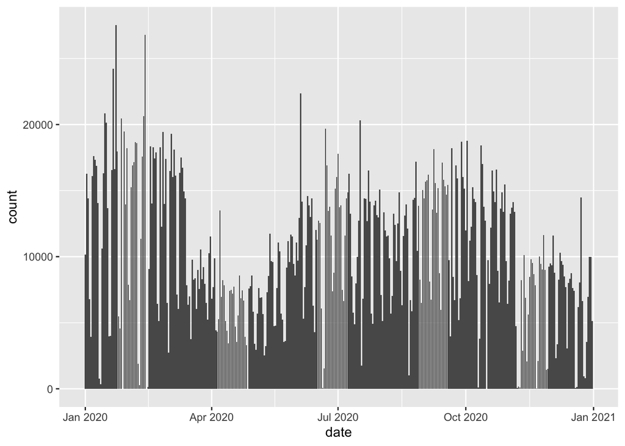

```r
ggplot(base) + aes(x=date) + geom_bar()
```

On verra par la suite que cette donnée peut s’agréger en semaines, mois ou trimestre mais il est inutile de le faire pour l’instant.

### La variable **dep** (*location_departement*)

On renomme la variable et on examine sa distribution :

```r
base$dep<-base$location_departement
tabdep<-base %>% count(dep) %>% arrange(-n)
head(tabdep)
```

```
  dep      n
1     237206
2  75 175777
3  69 164630
4  92 134828
5  33 122942
6  13 115264
```

```r
tail(tabdep)
```

```
    dep  n
112   7 16
113 987 13
114   5  8
115   8  7
116   9  6
117 986  3
```

- Y-a-t-il des valeurs manquantes ? : OUI
- Y-a-t-il des valeurs aberrantes ? : OUI

Ce fichier appelle plusieurs corrections. On supposera ici qu’on ne veut garder que les départements de France métropolitaine. Une solution simple pour les sélectionner consiste à ne retenir que les codes de deux caractères et éliminer le code “99” (pays étranger). En effet, les codes à 1 caractère sont des erreurs et les codes à 3 caractères des départements ou territoires d’outre mer.

```r
base <- base %>% mutate( dep = as.character(location_departement),
                         dep = case_when(dep=="99" ~ NA,
                                           nchar(dep)==2~ dep,
                                           .default = NA))
table(base$dep)
```

```
    01     02     03     04     05     06     07     08     09     10     11
 36555  16069  10887   8085   8170  60364  11764   9084   7372  13334  17558
    12     13     14     15     16     17     18     19     21     22     23
 12875 115264  36657   5694  18649  37900  14413  11791  32661  30828   4391
    24     25     26     27     28     29     2A     2B     30     31     32
 18743  29362  32504  22235  18850  48777   7011   6337  28605  91937   9583
    33     34     35     36     37     38     39     40     41     42     43
122942  62340  72542  10012  34576  79044  11943  21720  17383  35287   7593
    44     45     46     47     48     49     50     51     52     53     54
108137  38459   9732  21952   3860  51456  24050  29608   7134  16615  34572
    55     56     57     58     59     60     61     62     63     64     65
  7018  44911  45880   8170 111966  32915  11362  43774  33440  36642  12983
    66     67     68     69     70     71     72     73     74     75     76
 18182  67193  33736 164630   7304  24667  27769  38833  54366 175777  48790
    77     78     79
 58896  70602  21779
 [ reached getOption("max.print") -- omitted 16 entries ]
```

### Métadonnées géographiques et fonds de carte

Nous souhaitons ajouter au code le nom du département et pouvoir ensuite agréger en région. Nous voulons également faire des cartes pour représenter les résultats. Il faut donc charger une base de donnée géographique des départements que l’on va trouver (par exemple) sur le site suivant :

https://public.opendatasoft.com/explore/dataset/contours-geographiques-tres-simplifies-des-departements-2019/information/

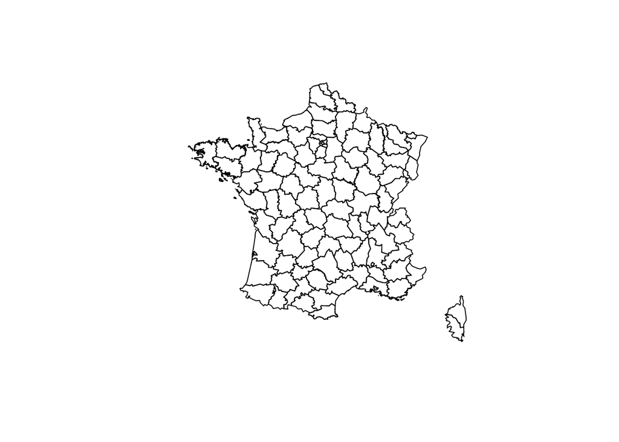

```r
myurl <- "https://public.opendatasoft.com/api/explore/v2.1/catalog/datasets/contours-geographiques-tres-simplifies-des-departements-2019/exports/geojson?lang=fr&timezone=Europe%2FBerlin"
map <- st_read(myurl)
map <- map %>% filter(nchar(insee_dep)==2) %>%st_transform(2154)
plot(map$geometry)
```

On décide de ne conserver que les variables utiles et on les renomme. On fait bien attention àce qu’une des variables soit le code des départements et permette la jointure avec notre base principale.

```r
map_dep <- map %>% select(dep = insee_dep,
                      dep_nom = nom_dep_min,
                      reg = insee_reg,
                      reg_nom = region_min)
saveRDS(map_dep,"jocas_france/data/map_dep.RDS")
```

On vérifie que ce fonds de carte peut s’agréger en régions et on sauvegarde le résultat

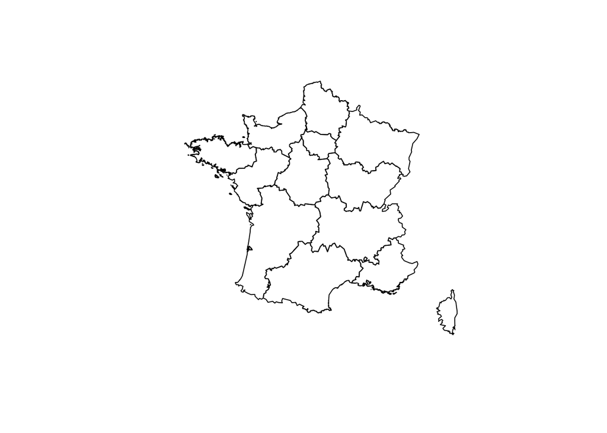

```r
map_reg <- map_dep %>% group_by(reg, reg_nom) %>%
                       summarise()
plot(map_reg$geometry)
```

```r
saveRDS(map_reg,"jocas_france/data/map_reg.RDS")
```

Pour finir on fait un test de jointure entre la base des annonces et le fonds de carte des départements.

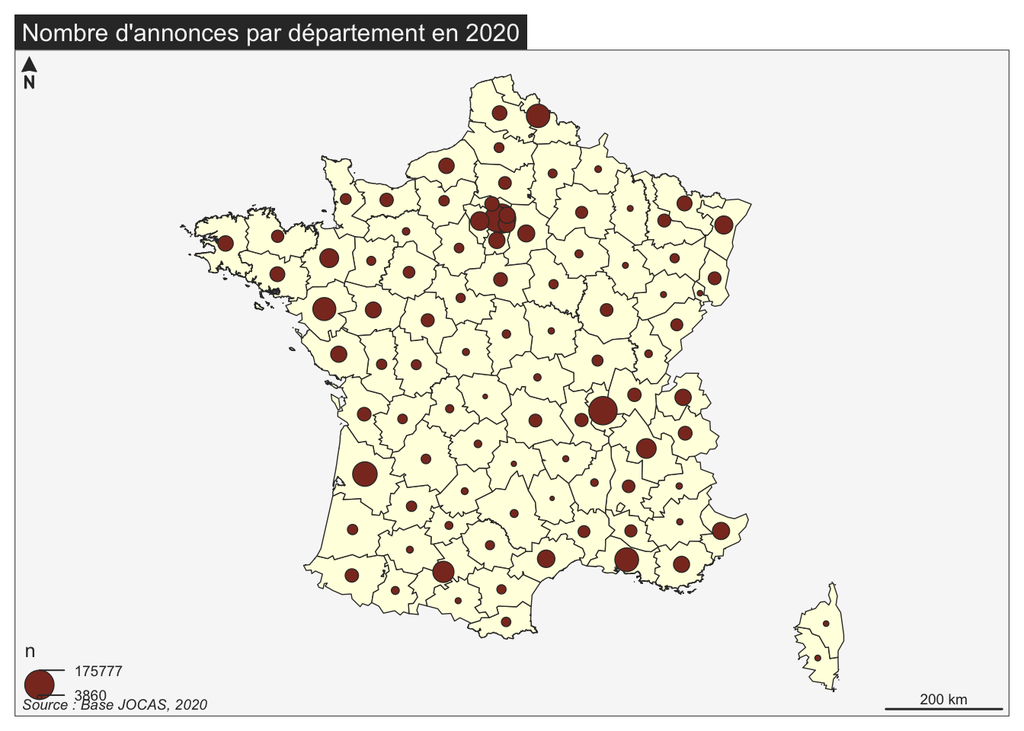

```r
# Agrégation
don<- base %>%   group_by(dep) %>%
                 count()
# Jointure
mapdon<-map_dep %>% left_join(don)

# Carte
mf_map(mapdon, type="base",
       col="lightyellow")
mf_map(mapdon, type="prop",
       inches=0.1,
       var ="n",
       add=TRUE)
mf_layout("Nombre d'annonces par département en 2020",
          frame=T,
          credits = "Source : Base JOCAS, 2020")
```

### La variable **job** (*job_ROME_Code*)

On examine maintenant la distribution de la variable décrivant le type d’activité proposée dans l’annonce selon leur code ROME. Quelle est l’activité la plus fréquente ? la moins fréquente ?

```r
base$job<-base$job_ROME_code
tabjob <- base %>% count(job) %>% arrange(-n)
head(tabjob)
```

```
    job      n
1 K1303 158656
2 M1203 102983
3 C1504  91175
4 J1506  89911
5 K1304  88992
6 K1302  87821
```

```r
tail(tabjob)
```

```
      job  n
527 L1501 10
528 B1402  9
529 E1202  8
530 K1904  8
531 L1301  2
532 B1801  1
```

On voit qu’il y a 532 types de métiers dans la base. Les métier les plus fréquents sont **K1303** et **M1203**. Les moins fréquents sont **B1801** et **L1301**. Mais comme on ignore quels sont ces métiers, c’est peu utile.

### Importation des codes ROME à trois niveaux

Nous avons besoin de récupérer la liste des codes ROME. On peut la trouver sur le site suivant où l’INSEE propose une correspondances entre code ROME et cde NACE : https://public.opendatasoft.com/explore/?sort=modified&q=ROME+code

```r
myurl <- "https://public.opendatasoft.com/api/explore/v2.1/catalog/datasets/pole-emploi-rome-arborescence-principale/exports/json?lang=fr&timezone=Europe%2FBerlin"
code<-fromJSON(myurl)
head(code)
```

```
  grand_domaine domaine_professionnel fiche_rome
1             M                    12         07
2             M                    12         07
3             M                    13         02
4             M                    14         01
5             M                    14         01
6             M                    14         02
                                           libelle code_ogr
1 Chargé / Chargée de trésorerie et de financement    11872
2                  Responsable relations bancaires    19168
3                        Chef d'agence commerciale    12022
4                                        Panéliste    17553
5   Testeur / Testeuse de produits de consommation    20310
6           Consultant / Consultante en management    13533
   libelle_grand_domaine domaine_pro libelle_domaine_professionnel code_rome
```

[output cut: 27 more lines]

Ce tableau très détaillé comporte 31977 lignes car il établit les correspondances entre ROME et NACE. On simplifie le tableau pour ne garder que les trois niveaux de code ROME et leur définition. On élimine la correspondance avec la NAF et on sauvegarde le tableau.

```r
code_rome<-code %>%   mutate(job=as.factor(code_rome),
                          job_name=as.factor(libelle),
                          dom =as.factor(paste0(grand_domaine,domaine_professionnel)),
                          dom_name =as.factor(libelle_domaine_professionnel),
                          big_dom = as.factor(grand_domaine),
                          big_dom_name = as.factor(libelle_grand_domaine)) %>%
                  select(job,
                         job_name,
                         dom,
                         dom_name,
                         big_dom,
                         big_dom_name) %>%
                    filter(duplicated(job)==F)

saveRDS(code_rome,"jocas_france/data/code_rome.RDS")
head(code_rome)
```

```
    job                                                         job_name dom
1 M1207                 Chargé / Chargée de trésorerie et de financement M12
2 M1302                                        Chef d'agence commerciale M13
3 M1401                                                        Panéliste M14
4 M1402                           Consultant / Consultante en management M14
5 M1403 Assistant chargé / Assistante chargée d'études socio-économiques M14
6 M1404   Chargé / Chargée de terrain - management et gestion d'enquêtes M14
                 dom_name big_dom           big_dom_name
1 Comptabilité et gestion       M Support à l'entreprise
2  Direction d'entreprise       M Support à l'entreprise
3  Organisation et études       M Support à l'entreprise
4  Organisation et études       M Support à l'entreprise
5  Organisation et études       M Support à l'entreprise
6  Organisation et études       M Support à l'entreprise
```

```r
dim(table(code_rome$job))
```

```
[1] 609
```

```r
dim(table(code_rome$dom))
```

```
[1] 110
```

```r
dim(table(code_rome$big_dom))
```

```
[1] 14
```

On peut ainsi facilement établir un tableau des offres d’emploi par domaines ou grand domaine

```r
tabdom <- base %>% left_join(code_rome) %>% count(big_dom_name) %>% arrange(-n)
kable(tabdom)
```

| big_dom_name | n |
| --- | --- |
| Services à la personne et à la collectivité | 620686 |
| Support à l’entreprise | 556109 |
| Commerce, Vente et Grande distribution | 477215 |
| Construction, Bâtiment et Travaux publics | 393740 |
| Industrie | 354556 |
| Santé | 336089 |
| Installation et Maintenance | 299854 |
| Transport et Logistique | 249622 |
| Hôtellerie-Restauration, Tourisme, Loisirs et Animation | 200451 |
| Banque, Assurance, Immobilier | 162720 |
| Agriculture et Pêche, Espaces naturels et Espaces verts, Soins aux animaux | 50527 |
| Communication, Média et Multimédia | 19270 |
| Arts et Façonnage d’ouvrages d’art | 3866 |
| Spectacle | 2880 |
| NA | 410 |

### La variable **typ** (*contractType*)

Cette variable décrit le type de contrat.

```r
base$typ <-as.factor(base$contractType)
summary(base$typ)
```

```
        CCE         CDD         CDI         CDS         DDI         DIN
      15582      685845     2225920         503        3243        1060
  Franchise Independant         MIS         REP         SAI         TTI
      26088       73010      647602        5634       42870         638
```

- Y-a-t-il des valeurs manquantes ? : NON
- Y-a-t-il des valeurs aberrantes ? : NON

La variable est propre, mais il y aura certainement lieu de procéder à des regroupements. On examinera la question ultérieurement.

### La variable **sal** (*salarly_hourly_mean*)

Il s’agit d’une variable quantitative fournissant une estimation du salaire horaire basée sur les informations données dans l’annonce. Comporte-te-elle des valeurs manquantes ou aberrantes ?

```r
base$sal <-base$salary_hourly_mean
tab<-table(is.na(base$sal))
tab
```

```
  FALSE    TRUE
1373171 2354824
```

```r
prop.table(tab)
```

```
    FALSE      TRUE
0.3683404 0.6316596
```

```r
summary(base$sal)
```

```
    Min.  1st Qu.   Median     Mean  3rd Qu.     Max.     NA's
     0.0     10.2     11.5     15.7     14.2 106149.0  2354824
```

- Y-a-t-il des valeurs manquantes ? : OUI (2.3 millions sur 3.7 soit 63%)
- Y-a-t-il des valeurs aberrantes ? : OUI (un salaire de 106149 € de l’heure est peu plausible)

On décide de garder pour l’instant toutes les valeurs. On verra par la suite comment traiter ce problème.

### La variable **dur** (*contractDuration_value*)

Il s’agit à nouveau d’une variable quantitative qui a été reconstituée à partir du texte de l’annonce.

```r
base$dur <-base$contractDuration_value
tab<-table(is.na(base$dur))
tab
```

```
  FALSE    TRUE
1374359 2353636
```

```r
prop.table(tab)
```

```
   FALSE     TRUE
0.368659 0.631341
```

```r
summary(base$dur)
```

```
   Min. 1st Qu.  Median    Mean 3rd Qu.    Max.    NA's
    0.0    43.0    87.0   123.7   130.0 22492.0 2353636
```

- Y-a-t-il des valeurs manquantes ? : OUI (2.3 millions sur 3.7 soit 63%)
- Y-a-t-il des valeurs aberrantes ? : OUI (un contrat de 22492 jours soit 61.6 ans est peu probable …)

On décide de garder pour l’instant toutes les valeurs. On verra par la suite comment traiter ce problème.

## Sauvegarde finale du tableau

On retient uniquement les nouvelles variables ce qui nous fait un tableau

```r
## Choix des colonnes
sel <- base %>% select(11:16)

# Premières lignes
kable(head(sel))

## Sauvegarde de la base nettoyée
saveRDS(sel, "jocas_france/data/jocas_france.RDS")
```

[output not shown]